# Hedonic Model for Home Price Prediction - Philadelphia

Jonathan Manurung

December 2023

# Introduction: Home Price Prediction Tools for Philadelphia

Philadelphia has a whole lot to offer, from public amenities such as parks and green spaces, accessibility to public transportation facilities, dinings and entertainment spots, to cultural and sport places and events. Philadelphia is also one of the most walkable cities in the nation, and still offer affordability and diversity in the city. These facts attract more people to live and work in this city.

Finding an ideal housing is the main challenge when people decided to move to this city. A house with a lot of surrounding public amenities, safe neighborhood, and offer a lot of internal features will be desirable, but in what price? Navigating house prices in this city can be challenging, thus a price prediction tool will be helpful to give initial information to the buyer.

This project’s objective is to create a tool to estimate a home’s market value based on a valuation model. Many similar housing market prediction tools are not as accurate as they could be because local intelligence factors are not associated well enough. An accurate model should incorporate public, Multiple Listing Service, and user-submitted data into a mathematical model, and also take home factors such as internal characteristic, location, and trends into account. Local tradition, lifestyle pattern, and proximity to favorite public amenities are important factors that must be taken into account in building the model. Deciding which internal factors, the preferences of city’s residents for various public amenities and neighborhoods presents a challenges in generating an appropriate model. This project associates significant variables from house’s internal characteristics, house’s proximity to public amenities and disamenities, and the recent transactions information.

# Data: Internal Characteritics, Proximity to Amenities, and Recent Transaction

This project involved a range of data sources for finding key insights of the home price prediction model building. Primarily in the house’s internal characteristic such as sale price, number of bedrooms, floors, house type, zoning, lot size, interior and exterior condition, and house’s age. These information gathered from the Philadelphia property assessment data.

This predictive tool will also incorporate proximity to public amenities variables such as parks, public transit facilities, universities, and health facilities. Proximity to city parks gives easier access to nature and recreation which have number of amenities and facilities. Living close to health facilities gives a convenience and immediate access to healthcare. These factor will also increase the opportunity to generate passive income from providing housing for health workers, patients and families, and also to attract investors. This economic opportunity also applies to buildings near universities or colleges, as they have the potential to generate passive income by providing student housing. Meanwhile, living in buildings which are just steps away from train stations and bus stops will be beneficial for frequent commuters. As the result, people are willing to pay premium price for houses near this public transit amenities. While proximity to public amenities offers clear benefits, a high crime rate is one of the most significant drawbacks—or disamenities of a property.Therefore, the number of crime incidents in the neighborhood and how close a house sits from a crime locations, particularly drugs violation, serves as a variable in this framework. These information mainly gathered from Philadelphia open data portal and then underwent data wrangling to produce more useful insights.

Two feature engineering techniques were applied to define the relationship and exposure of public amenities and (dis)amenities variables to the house prices. First technique would sum the value of the amenities within a fixed buffer distance (0.125 mile) of each home sale observation. Variables like number of parks and number of universities can use this approach because their influence is generally localized and can be meaningfully captured within a defined area. Meanwhile amenity variables such as train (subway), health facilities, and (dis)amenities such as crime incidents can be more meaningfully explained by their distance to each home sale observation using k-nearest neighbor distance. Aggregating crime incidents within a fixed buffer distance from each home sale observation will create uniformity of home prices citywide, which is not likely accurate too.

## Variables: Numerical and Categorical

Understanding variables that influence house prices requires a clear overview of the data used in the analysis. The table below summarizes all relevant variables used in building this predictive model, including their descriptions and key statistics (See Table 1). Variables are categorized as numerical, for features such as age of house, total livable area, distance from crime incidents, number of park within buffer, distance from nearest train station, number of university building within buffer, and distance from nearest health facility. Meanwhile, the categorical variable including number of stories, number of bedrooms, interior condition, exterior condition, building style (type), and zoning area. For clarity, the variables are grouped by internal characteristics and proximity to amenities/public services and (dis)amenities aspects that may impact property values.

```r
numeric_variable <- c("Age", "total_livable_area","crime_nn1", "park.Buffer", "subway_nn1", "univ.Buffer", "health_nn1")

categorical_variable <- c("number_stories", "number_of_bedrooms", "interior_condition", "exterior_condition",
                      "building_code_description_new", "zoning")


internal_characteristics <- c("Age", "total_livable_area", "number_stories", "number_of_bedrooms",
                              "interior_condition", "exterior_condition", "building_code_description_new",
                              "zoning")
proximity_amenities <- c("crime_nn1","park.Buffer", "subway_nn1", "univ.Buffer", "health_nn1")

variable_table <- c(numeric_variable, categorical_variable)

data_subset <- home_price[, variable_table]
data_subset$geometry <- NULL  # remove sf geometry if needed


variable_descriptions <- data.frame(
  Variable = variable_table,
  Description = c("Age of house", "Total livable area", "Nearest crime count (KNN)",
                  "Number of parks within buffer", "Distance to nearest subway",
                  "Number of universities within buffer", "Distance to nearest health facility",
                  "Number of stories", "Number of bedrooms", "Interior condition",
                  "Exterior condition", "Building type description", "Zoning code"),
  Category = ifelse(variable_table %in% proximity_amenities,
                    "Proximity to Amenities",
                    "Internal Characteristics"),
  stringsAsFactors = FALSE
)


numeric_summary <- data.frame(
  Variable = numeric_variable,
  Mean = sapply(data_subset[, numeric_variable], mean, na.rm = TRUE),
  Median = sapply(data_subset[, numeric_variable], median, na.rm = TRUE),
  SD = sapply(data_subset[, numeric_variable], sd, na.rm = TRUE),
  Min = sapply(data_subset[, numeric_variable], min, na.rm = TRUE),
  Max = sapply(data_subset[, numeric_variable], max, na.rm = TRUE)
)


categorical_summary <- data.frame(
  Variable = categorical_variable,
  Most_Frequent = sapply(data_subset[, categorical_variable], function(x) {
    ux <- na.omit(x)
    ux_tab <- table(ux)
    names(ux_tab)[which.max(ux_tab)]
  }),
  Count = sapply(data_subset[, categorical_variable], function(x) {
    ux <- na.omit(x)
    ux_tab <- table(ux)
    max(ux_tab)
  })
)


summary_stats <- variable_descriptions %>%
  left_join(numeric_summary, by = "Variable") %>%
  left_join(categorical_summary, by = "Variable")


summary_stats$Category <- factor(summary_stats$Category, levels = c("Internal Characteristics", "Proximity to Amenities"))
summary_stats <- summary_stats %>% arrange(Category)


kable(summary_stats, format = "html", caption = "Table 1. Summary Statistics of Variables by Category") %>%
  kable_styling(full_width = FALSE, position = "left")
```

Table 1. Summary Statistics of Variables by Category

| Variable | Description | Category | Mean | Median | SD | Min | Max | Most_Frequent | Count |
| --- | --- | --- | --- | --- | --- | --- | --- | --- | --- |
| Age | Age of house | Internal Characteristics | 87.317952 | 99.0000 | 51.067703 | 0.0000000 | 2024.000 | NA | NA |
| total_livable_area | Total livable area | Internal Characteristics | 1333.632846 | 1208.0000 | 548.834289 | 0.0000000 | 15246.000 | NA | NA |
| number_stories | Number of stories | Internal Characteristics | NA | NA | NA | NA | NA | 2 | 16789 |
| number_of_bedrooms | Number of bedrooms | Internal Characteristics | NA | NA | NA | NA | NA | 3 | 15015 |
| interior_condition | Interior condition | Internal Characteristics | NA | NA | NA | NA | NA | 4 | 16983 |
| exterior_condition | Exterior condition | Internal Characteristics | NA | NA | NA | NA | NA | 4 | 17715 |
| building_code_description_new | Building type description | Internal Characteristics | NA | NA | NA | NA | NA | ROW PORCH FRONT | 6678 |
| zoning | Zoning code | Internal Characteristics | NA | NA | NA | NA | NA | RSA5 | 15355 |
| crime_nn1 | Nearest crime count (KNN) | Proximity to Amenities | 432.346670 | 291.2997 | 451.533649 | 0.8524574 | 4023.481 | NA | NA |
| park.Buffer | Number of parks within buffer | Proximity to Amenities | 1.178678 | 1.0000 | 1.000473 | 0.0000000 | 5.000 | NA | NA |
| subway_nn1 | Distance to nearest subway | Proximity to Amenities | 4292.669840 | 3634.7312 | 3485.648027 | 32.5217862 | 16356.989 | NA | NA |
| univ.Buffer | Number of universities within buffer | Proximity to Amenities | 1.784054 | 0.0000 | 7.407117 | 0.0000000 | 132.000 | NA | NA |
| health_nn1 | Distance to nearest health facility | Proximity to Amenities | 1801.446289 | 1136.9180 | 1878.339698 | 24.5968029 | 10663.569 | NA | NA |

## Correlation across variables

Correlation among the variables are important in building accurate house price predictive mode, as it helps identify features that may be useful for predicting the sale prices. A matrix is created to visualize correlation across numeric variables used in building this predictive model (See Figure 1). Correlation between different public amenities and (dis)amenities to the house sale price can be understood by the visualization in this scatterplots (see Figure 2). By visualizing these relationships, we can identify patterns and detect how meaningful our predictors are in determining housing prices across Philadelphia.

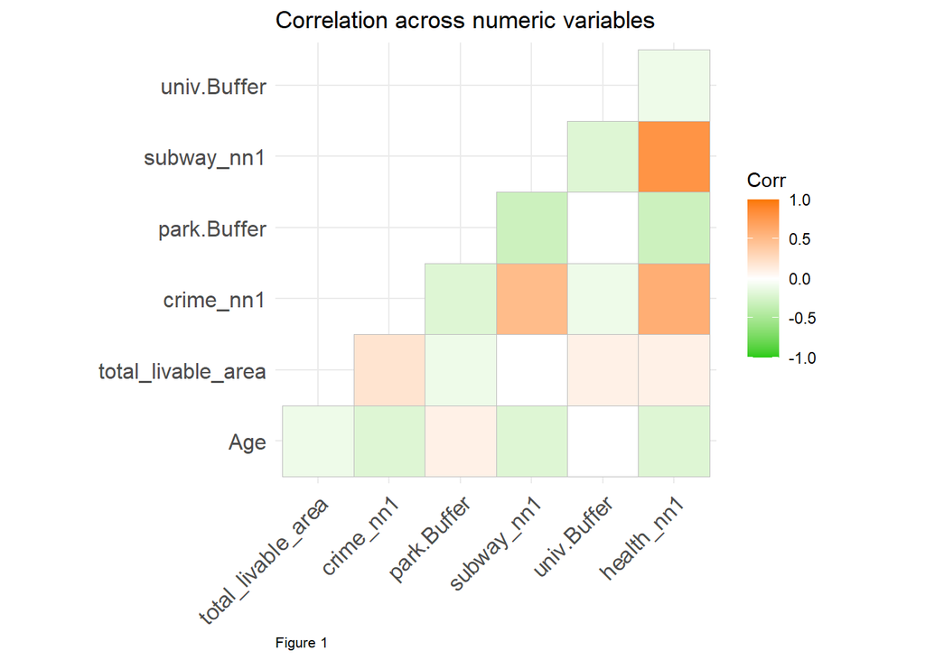

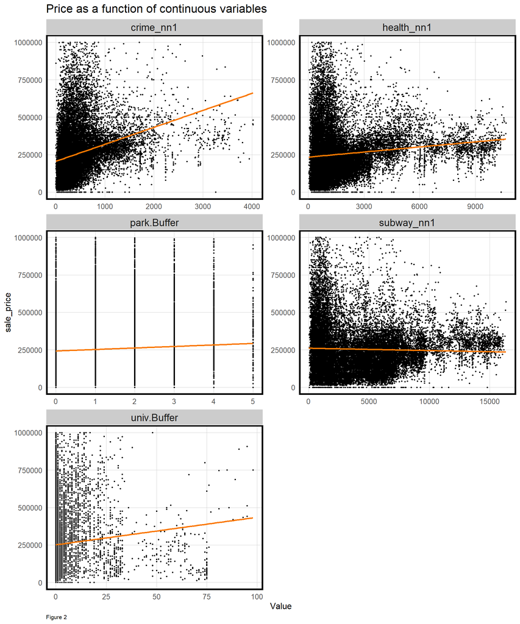

## Visualizing House Sale Price Variables

The maps and charts provide a clear visualization of the primary data, highlighting the house prices across the city, the average house price in every Philadelphia’s neighborhood, and the house prices distribution across the city. Houses with higher price located in Rittenhouse and around Center City, also in the Northwest of Center City, particularly in Chesnut Hill, Mount Airy West, Manayunk and some part of the Germantown neighborhood. Meanwhile, majority of the house prices are clustered below $500,000 (see Figure 3)

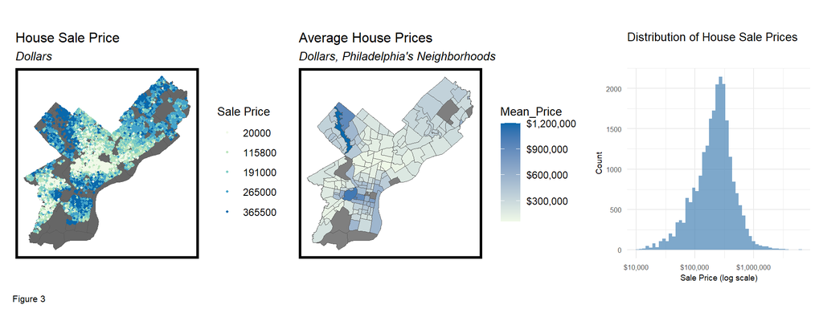

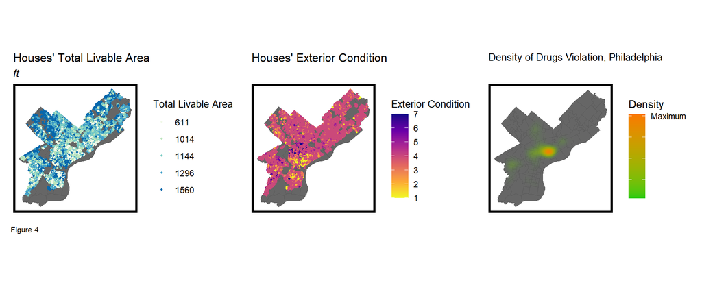

These maps provide visualization of how each independent variables discussed distributed across Philadelphia. Houses with larger total livable area located around Mount Airy West, Chesnut Hill, Germantown, and Manayunk. Significant numbers also located in Rittenhouse and Spruce Hill. House with good exterior condition (1 = best, 7 = worst) are located around Lower North Philadelphia, primarily in Spring Garden and Ludlow. Significant number of houses also located in Manayunk, Ritten House, and South Philadelphia around Point Breeze neighborhood. The map also shows the (dis)amenity factor of drug violation incidents, which are concentrated in Upper Kensington.

# Methods: Building the Model

Having explored and summarized the independent variables, a prediction tool for house prices is developed based on a hedonic model. A hedonic model estimates house prices as a function of both property characteristics and neighborhood features (Rosen, 1974). In building this house predictive tool, Linear Regression or Ordinary Least Squares Regression (OLS) approach, is used to model the relationship between house prices and the selected independent variables.

The first step of building the model is to clean the dataset. This step is critical to ensure all the downstream work will give accurate result. This step includes treating NAs or missing values in a “Missing” category, to avoid misleading values and allow the model to learn patterns associated with missingness. Further feature engineering is performed to the cleaned data to simplify the number of categories in all categorical independent variables, thus reducing model complexity, improve generalization and avoid overfitting, and provide easier interpretation.

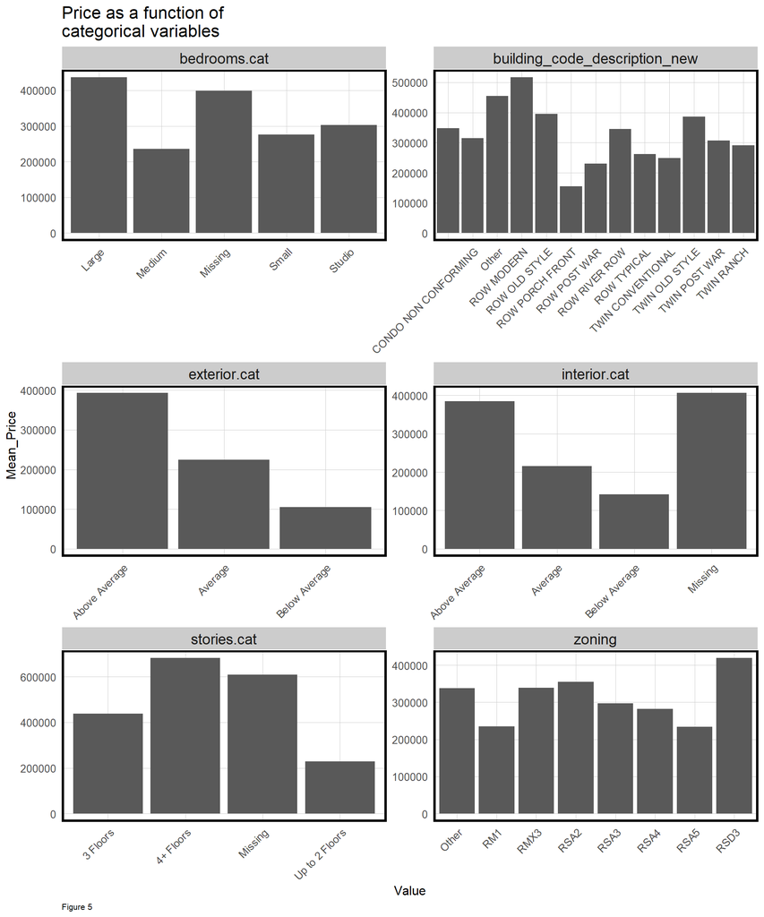

# Results: Model Building Interpretation

Cleaned dataset then splitted into two datsets: “Modelling” dataset and “Prediction” dataset. The “Modelling” dataset, which contains the complete sale price information, is split into “Training” and “Testing” datasets with a 60:40 ratio to build the house price model. OLS model is trained using the selected independent variables, and the statistical summary explained in the table (See Table 2)

## Statistics: Linear Regression Model

Table 2. Linear Regression Summary

| term | estimate | std.error | statistic | p.value |
| --- | --- | --- | --- | --- |
| (Intercept) | 11.7645840 | 0.1110392 | 105.9498629 | 0.0000000 |
| MAPNAMEAllegheny West | -0.5031064 | 0.1010282 | -4.9798622 | 0.0000006 |
| MAPNAMEAndorra | 0.0868200 | 0.1042537 | 0.8327768 | 0.4049829 |
| MAPNAMEAston-Woodbridge | 0.0584134 | 0.0914054 | 0.6390589 | 0.5227936 |
| MAPNAMEBartram Village | -0.3760177 | 0.1300985 | -2.8902540 | 0.0038544 |
| MAPNAMEBella Vista | 1.1202318 | 0.1089095 | 10.2858941 | 0.0000000 |
| MAPNAMEBelmont | -0.2186702 | 0.1088922 | -2.0081344 | 0.0446455 |
| MAPNAMEBlue Bell Hill | 0.5853231 | 0.1623755 | 3.6047512 | 0.0003134 |
| MAPNAMEBrewerytown | 0.3345032 | 0.1000247 | 3.3442071 | 0.0008270 |
| MAPNAMEBridesburg | 0.1632908 | 0.0885159 | 1.8447621 | 0.0650903 |
| MAPNAMEBurholme | 0.3379061 | 0.1136604 | 2.9729442 | 0.0029539 |
| MAPNAMEBustleton | 0.1482213 | 0.0727213 | 2.0382118 | 0.0415449 |
| MAPNAMEByberry | -0.4645224 | 0.1534796 | -3.0266060 | 0.0024770 |
| MAPNAMECallowhill | 0.9674939 | 0.2132539 | 4.5368171 | 0.0000058 |
| MAPNAMECarroll Park | -0.4583356 | 0.0868270 | -5.2787201 | 0.0000001 |
| MAPNAMECedar Park | 0.5621642 | 0.0980481 | 5.7335523 | 0.0000000 |
| MAPNAMECedarbrook | 0.1780512 | 0.0926328 | 1.9221192 | 0.0546082 |
| MAPNAMEChestnut Hill | 0.6711218 | 0.0903707 | 7.4263215 | 0.0000000 |
| MAPNAMEChinatown | 0.7316742 | 0.4223775 | 1.7322756 | 0.0832435 |
| MAPNAMEClearview | 0.0470367 | 0.1168076 | 0.4026849 | 0.6871853 |
| MAPNAMECobbs Creek | -0.1611821 | 0.0836249 | -1.9274425 | 0.0539419 |
| MAPNAMECrescentville | 0.1787335 | 0.2021497 | 0.8841638 | 0.3766209 |
| MAPNAMECrestmont Farms | 0.3317253 | 0.3001606 | 1.1051596 | 0.2691068 |
| MAPNAMEDearnley Park | 0.1238736 | 0.1062251 | 1.1661428 | 0.2435738 |
| MAPNAMEDickinson Narrows | 0.7827114 | 0.1079929 | 7.2478053 | 0.0000000 |
| MAPNAMEDunlap | -0.2648459 | 0.1175269 | -2.2534918 | 0.0242414 |
| MAPNAMEEast Falls | 0.6330708 | 0.0948987 | 6.6710193 | 0.0000000 |
| MAPNAMEEast Germantown | -0.2085750 | 0.0998163 | -2.0895890 | 0.0366702 |
| MAPNAMEEast Kensington | 0.6526579 | 0.0990283 | 6.5906192 | 0.0000000 |
| MAPNAMEEast Mount Airy | 0.2462802 | 0.0907866 | 2.7127371 | 0.0066800 |

[output cut: 158 more lines]

Table 3. Linear Regression Model Statistics

| r.squared | adj.r.squared | sigma | statistic | p.value | df | logLik | AIC | BIC | deviance | df.residual | nobs |
| --- | --- | --- | --- | --- | --- | --- | --- | --- | --- | --- | --- |
| 0.7264517 | 0.7233055 | 0.4092789 | 230.9005 | 0 | 187 | -8549.673 | 17477.35 | 18934.14 | 2723.532 | 16259 | 16447 |

Table 4. Goodness of fit

| Metric | Value |
| --- | --- |
| Mean Absolute Error (MAE) | 58080.5803359 |
| Mean Absolute Percentage Error (MAPE) | 0.3283183 |

## Generalizability: Cross-validation

K-Fold Cross-validation is conducted to ensure this modeling approach perform well on new and unseen data. Data from the home price dataset splitted into k=100 equal sized subsets. For a given fold, model trained on a subset of observations, and predict on a test set, and measure goodness of fit. The average goodness of fit across all k fold then calculated as explained in the table and graph below (see Table 5 and Figure 6).

Table 5. Linear Regression Cross-Validation Summary

| Metric | Value |
| --- | --- |
| RMSE | 0.411 |
| Rsquared | 0.721 |
| MAE | 0.297 |

[figure not shown]

Predicted prices are plotted as a function of observed prices (See Figure 7). The orange line represents the observed prices while the green line represents the predicted fit.

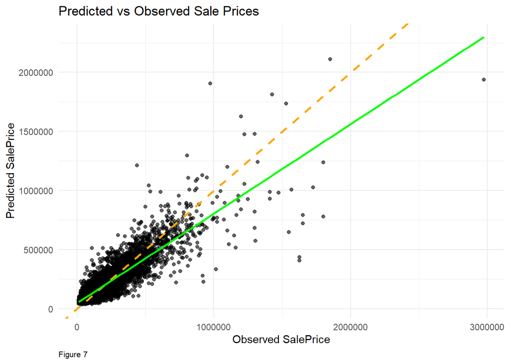

```r
ggplot(filter(home_price_test, sale_price < 3000000), aes(x = sale_price, y = sale_price.Predict)) +
  geom_point(alpha = 0.6) +  # scatter points
  geom_abline(slope = 1, intercept = 0, color = "orange", linetype = "dashed", size = 1) +  # perfect fit line
  geom_smooth(method = "lm", color = "green", se = FALSE, size = 1) +  # average predicted fit
  labs(
    title = "Predicted vs Observed Sale Prices",
    x = "Observed SalePrice",
    y = "Predicted SalePrice",
    caption = "Figure 7"
  ) +
  theme_minimal()+
  theme(plot.caption = element_text(size = 8, hjust = 0))
```

## Spatial Lag: Do prices & errors cluster?

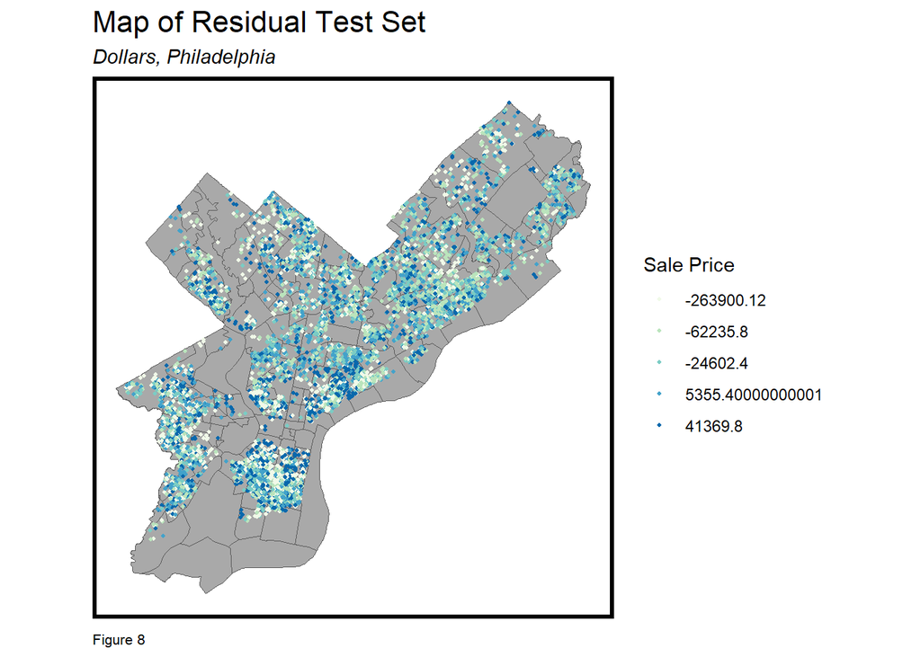

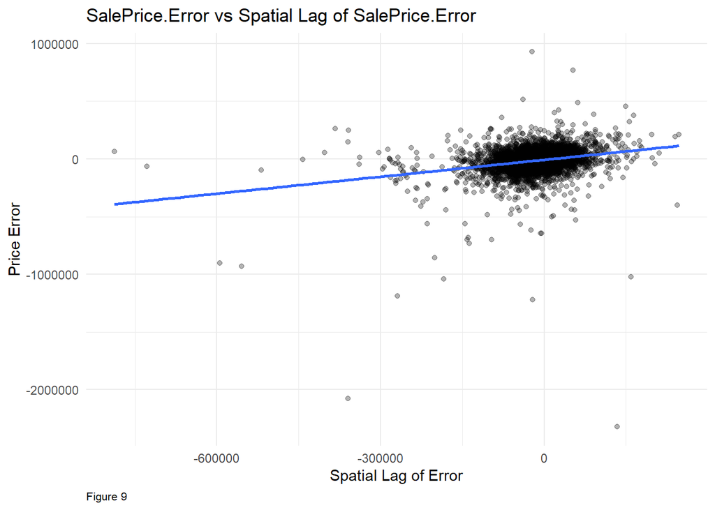

```r
ggplot()+
  geom_sf(data = neighborhood, fill = "darkgray")+
  geom_sf(data = home_price_test, aes(color = q5(sale_price.Error)),
          show.legend = "point", size = .75) +
  scale_color_manual(values = palette5,
                     labels = qBr(home_price_test, "sale_price.Error"),
                     name= "Sale Price")+
  labs(title = "Map of Residual Test Set", subtitle = "Dollars, Philadelphia", caption = "Figure 8")+
  mapTheme()+
  theme(plot.caption = element_text(size = 8, hjust = 0))
```

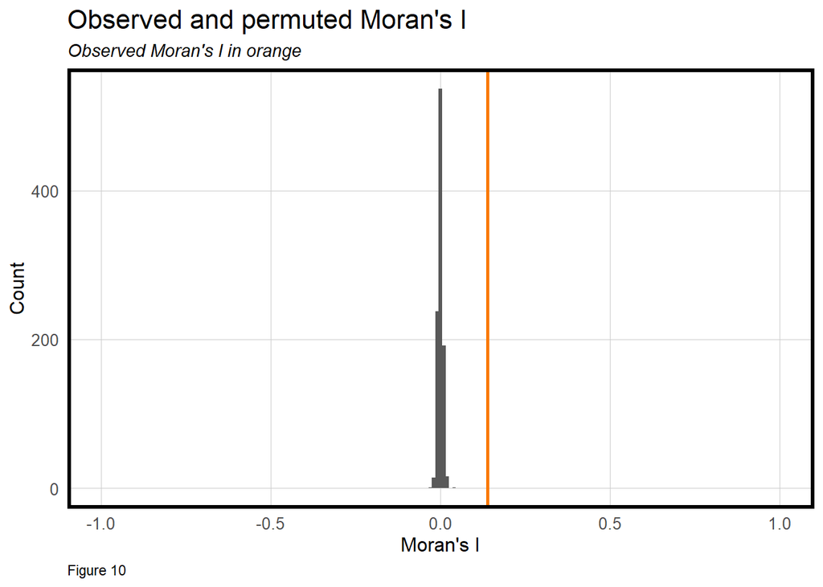

## Model Prediction Result

The linear regression model is used to predict house prices across Philadelphia. This following map presents the house prices for both Modeling and and Challenge dataset (see Figure 11)

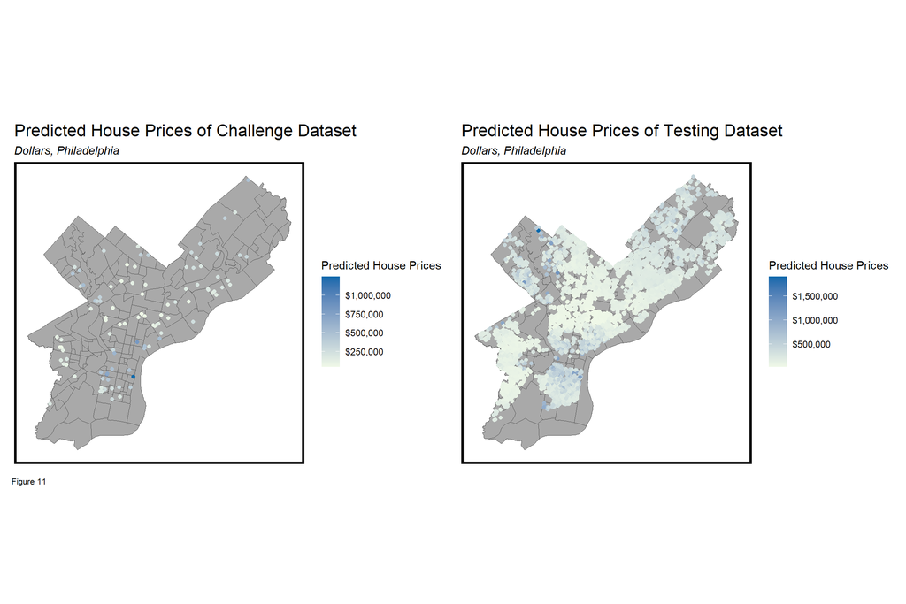

## Generalizability of the model

Measuring the generalizability, in this context the ability to predict with comparable accuracy across different neighborhood context, is important to see if a geospatial predictive model generalize to different neighborhood context. In general, generalizability across space is very challenging with OLS, because it focuses on relationship at the mean. These map and scatter plot presents the mean absolute percentage error (MAPE) by neighborhood and as a function of mean price by neighborhood from the test set predictions (see Figure 12 and Figure 13).

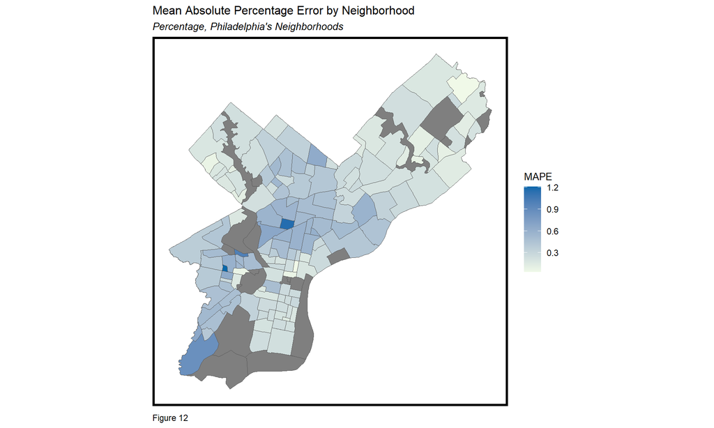

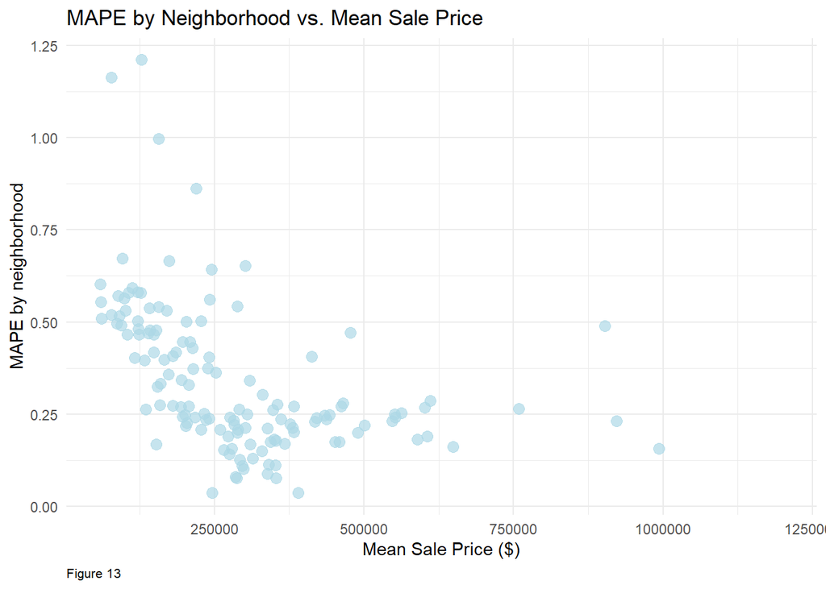

The second approach to test the generalizability is by using census data to test how well the model generalizes to different group contexts, in this case, race and income. Using tidycensus, the study area are splitted into two groups, race context and income context (see Figure 14). These plots shows that Philadelphia is segregated with respect to both race and income.

[output not shown]

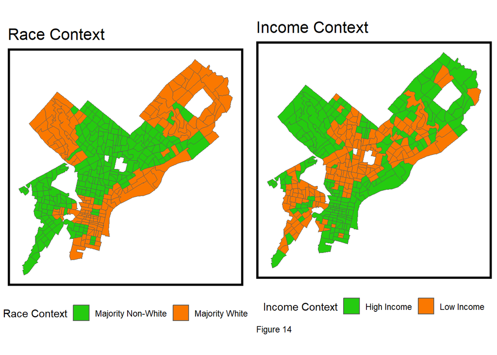

MAPE from this OLS model is calculated across the races and income, and we can see that this model generalizes better in predicting in high income and majority white neighborhood compared to prediction in low income and majority non-white neighborhood.

Test set MAPE by neighborhood racial context

| raceContext | mean.MAPE |
| --- | --- |
| Majority Non-White | 39% |
| Majority White | 23% |

Table 6. Test set MAPE by neighborhood income context

| incomeContext | mean.MAPE |
| --- | --- |
| High Income | 25% |
| Low Income | 42% |

# Discussion: Is this an effective model?

As mentioned before, generalizability across space is very challenging with OLS because it focuses on relationship at the mean. What makes the home prices so difficult to predict is that prices are clustered at different spatial scales. This model has accounted for the neighborhood scale, but other spatial relationships, that exist at smaller scales, have not been accounted.

This model is not fully generalizable as we can see a relatively huge different in MAPE across groups (race and income). This might happened because the model may rely heavily on features correlated with White-majority neighborhood and high-income neighborhoods. Spatial or socioeconomic factors not captured in the model might affect prices differently in Non-White majority neighborhood and low-income neighborhood.

As conclusion, this model is not recommended to Zillow because it predicts relatively poorly. There are some recommendation to improve this model, including: consider adding more features that capture neighborhood characteristic, and involve more samples across groups in the neighborhood for data training set.